# TreeClassification-HighRes

Aitor Apaolaza

09/01/2016

*Copyright (c) 2015 The University of Manchester, UK.*

*Licenced under LGPL version 2.1. See LICENCE for details.*

*The IDInteraction Processing Pipelines were developed in the IDInteraction project, funded by the Engineering and Physical Sciences Research Council, UK through grant agreement number EP/M017133/1.*

*Author: Aitor Apaolaza*

## Initialisation and loading data

```
## [1] "All listed packages are already installed"
```

# Setup for the classification algorithm.

**Folder**: /home/aitor/Dropbox/UoM/IDInteractionCode/Rnotebooks

**Experiment**: dual_screen_free_experiment

**Source Videos**: high_quality

**Tracking system**: front_full_face

**Using the following list of participants**: P01, P03, P04, P05, P06, P08, P09, P10, P12.

Data for these participants will be read from the CSV files contained in the following folders:

/home/aitor/Dropbox/UoM/IDInteractionCode/Rnotebooks/resources/dual_screen_free_experiment/high_quality/attention/

/home/aitor/Dropbox/UoM/IDInteractionCode/Rnotebooks/resources/dual_screen_free_experiment/high_quality/front_full_face/

Loading data

```
## [1] "Processing participant: P01"
## [1] "START of combineCSVsToDF()"
## [1] "END of combineCSVsToDF()"
## [1] "START of createFeatureDF()"
## [1] "END of createFeatureDF()"
## [1] "Processing participant: P03"
## [1] "START of combineCSVsToDF()"
## [1] "END of combineCSVsToDF()"
## [1] "START of createFeatureDF()"
## [1] "END of createFeatureDF()"
## [1] "Processing participant: P04"
## [1] "START of combineCSVsToDF()"
## [1] "END of combineCSVsToDF()"
## [1] "START of createFeatureDF()"
## [1] "END of createFeatureDF()"
```

[output cut: 30 more lines]

From a total of 408944 rows, 2/3 of them (273748) will be used for training, and 1/3 for testing (135196).

## Training the tree classifier

Using the **rpart** library for the following formula:

**attentionName ~ boxHeight + boxRotation + boxArea + boxWidth + widthHeightRatio + boxYcoord**

Resulting model:

```
## n= 273748
##
## node), split, n, loss, yval, (yprob)
##       * denotes terminal node
##
##  1) root 273748 85515 tv (0.3121082163 0.6876141561 0.0002776276)
##    2) boxArea< 1179.684 39894  8690 ipad (0.7821727578 0.2170501830 0.0007770592)
##      4) widthHeightRatio< 0.9687531 36741  5929 ipad (0.8386271468 0.1613728532 0.0000000000) *
##      5) widthHeightRatio>=0.9687531 3153   423 tv (0.1243260387 0.8658420552 0.0098319061) *
##    3) boxArea>=1179.684 233854 54280 tv (0.2319182054 0.7678893669 0.0001924278)
##      6) boxYcoord>=96.1881 57242 25528 tv (0.4459662486 0.5540337514 0.0000000000)
##       12) boxHeight< 36.0158 15465  2758 ipad (0.8216618170 0.1783381830 0.0000000000) *
##       13) boxHeight>=36.0158 41777 12821 tv (0.3068913517 0.6931086483 0.0000000000) *
##      7) boxYcoord< 96.1881 176612 28752 tv (0.1625427491 0.8372024551 0.0002547958) *
```

From the R manual for the Complexity Parameter Table for an Rpart Fit: *The cptable in the fit contains the mean and standard deviation of the errors in the cross-validated prediction against each of the geometric means.*

Matrix of information on the optimal prunings based on a complexity parameter.

```
##
## Classification tree:
## rpart(formula = formula, data = trainsetclass, method = "class")
##
## Variables actually used in tree construction:
## [1] boxArea          boxHeight        boxYcoord        widthHeightRatio
##
## Root node error: 85515/273748 = 0.31239
##
## n= 273748
##
##         CP nsplit rel error  xerror      xstd
## 1 0.263638      0   1.00000 1.00000 0.0028356
## 2 0.058171      1   0.73636 0.73658 0.0025752
## 3 0.027340      3   0.62002 0.62143 0.0024200
## 4 0.010000      4   0.59268 0.59411 0.0023787
```

Visualisation of the Complexity Parameter Table. *A good choice of cp for pruning is often the leftmost value for which the mean lies below the horizontal line.*

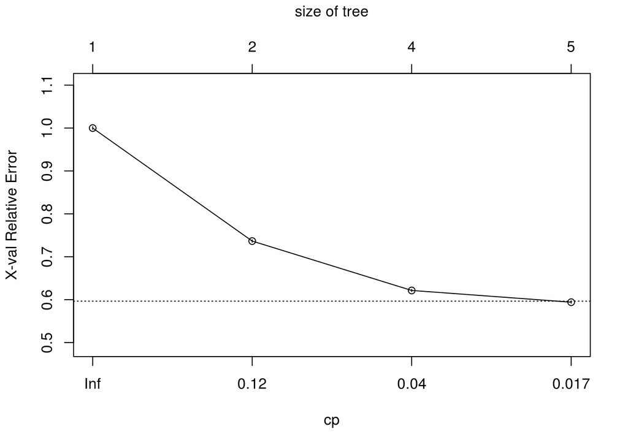

## Tree

### Summary of the tree

```
##
## Model formula:
## attentionName ~ boxHeight + boxRotation + boxArea + boxWidth +
##     widthHeightRatio + boxYcoord
##
## Fitted party:
## [1] root
## |   [2] boxArea < 1179.6839
## |   |   [3] widthHeightRatio < 0.96875: ipad (n = 36741, err = 16.1%)
## |   |   [4] widthHeightRatio >= 0.96875: tv (n = 3153, err = 13.4%)
## |   [5] boxArea >= 1179.6839
## |   |   [6] boxYcoord >= 96.1881
## |   |   |   [7] boxHeight < 36.0158: ipad (n = 15465, err = 17.8%)
## |   |   |   [8] boxHeight >= 36.0158: tv (n = 41777, err = 30.7%)
## |   |   [9] boxYcoord < 96.1881: tv (n = 176612, err = 16.3%)
##
## Number of inner nodes:    4
## Number of terminal nodes: 5
```

### Visualisation of the tree

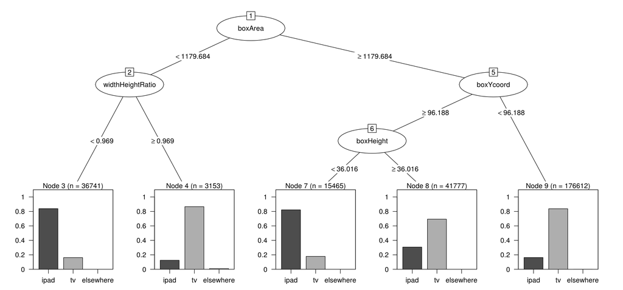

## Error metrics analysis

Confusion matrix from the application of the tree predictor to the testing set of data.

```
##            predclass
##              ipad    tv elsewhere
##   ipad      21534 20599         0
##   tv         4224 88799         0
##   elsewhere     0    40         0
```

### Error metrics based on prediction of attention to the iPad.

True negatives: 88799

False negatives: 4224

True positives: 21534

False positives: 20599

**Error-rate**: the proportion of the incorrectly classified examples -> (fp+fn)/(tp+tn+fp+tn)

**18.3661843**

**Accuracy**: the proportion of the correctly classified examples -> (tp+tn)/(tp+tn+fp+tn)

**81.6338157**

As the number of instances of the response variable is not balanced (there are many more instances with false than true) the accuracy is not a good indicator. Other cost sensitive measures are reported here. -> cost sensitive measures

**Precision**: positive predicted value (PPV) -> tp/(tp+fp), a measure of exactness

**51.1095816**

**Recall/Sensitivity**: true positive recognition rate -> tp/(tp+fn), a measure of completeness

**83.6012113**

**Specificity**: true negative recognition rate -> tn/(tn+fp)

**81.1705881**

**F measure**: the balance between precision and recall -> 2*tp/(2*tp+fp+fn)

**63.4369799**

### Error metrics based on prediction of attention to the TV.

True negatives: 21534

False negatives: 20599

True positives: 88799

False positives: 4224

**Error-rate**: the proportion of the incorrectly classified examples -> (fp+fn)/(tp+tn+fp+tn)

**18.3661843**

**Accuracy**: the proportion of the correctly classified examples -> (tp+tn)/(tp+tn+fp+tn)

**81.6338157**

**Precision**: positive predicted value (PPV) -> tp/(tp+fp), a measure of exactness

**95.4591875**

**Recall/Sensitivity**: true positive recognition rate -> tp/(tp+fn), a measure of completeness

**81.1705881**

**Specificity**: true negative recognition rate -> tn/(tn+fp)

**83.6012113**

**F measure**: the balance between precision and recall -> 2*tp/(2*tp+fp+fn)

**87.7369443**